# Collection-demo

This example is a bit contrived, but it demonstrates the basic features of a Trieste `Collection` in a simple way. We will load a color image, break it into three channels (R, G, B), and store each channel in a 2-D Trieste `Array`. The three `Array`s will then be stored in a `Collection`, which will be saved to disk and then read from disk. Finally, the contents of the file will be examined.

```python
%pylab notebook
```

```python
import trieste as tr
```

Let's begin by loading the image:

```python
image = plt.imread("IMG_2054.jpg")
```

This is what the image looks like:

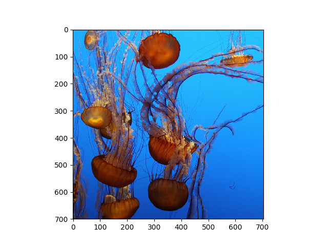

```python
plt.imshow(image)
```

```python
plt.close()
```

The `image` object is a 3-dimensional NumPy array. We can decompose it into red, green and blue channels:

```python
red = image[:,:,0]

green = image[:,:,1]

blue = image[:,:,2]
```

Now, we can store each channel in a Trieste `Array`:

```python
R = tr.Array(red)

G = tr.Array(green)

B = tr.Array(blue)
```

These three 2-dimensional `Array` objects can be stored together in a `Collection`. Let's add some metadata---a caption:

```python
meta = {'caption': 'This is a caption for the photo taken in 2010 at the Monterey Bay Aquarium.'}
```

```python
jelly = tr.Collection([R,G,B], name='jellyfish', metadata=meta)
```

You can add a documentation string / README page to the collection to explain what it is:

```python
read_me = """
This is potentially a long document describing the content of this Collection.
"""
```

```python
jelly.set_readme(read_me)
```

Save the collection as a file:

```python
jelly.save_as('jellies')
```

Now, we can load the file:

```python
J = tr.load('jellies.npz')
```

```python
J.name
```

```
'jellyfish'
```

Since the file only contains one top-level object (a `Collection`), the `load()` function creates a `Collection` object, rather than a `File` object:

```python
J
```

```
<jellyfish: a Collection of 3 2-D Arrays>
```

```python
type(J)
```

```
trieste.core.Collection
```

```python
print(J.readme)
```

```
This is potentially a long document describing the content of this Collection.
```

The table of contents for the `Collection`:

```python
J.toc
```

```
['red', 'green', 'blue']
```

A `Collection` can be indexed using the name of an object that it contains, as in:

```python
J['red']
```

```
<red: a Trieste 2-D Array>
```

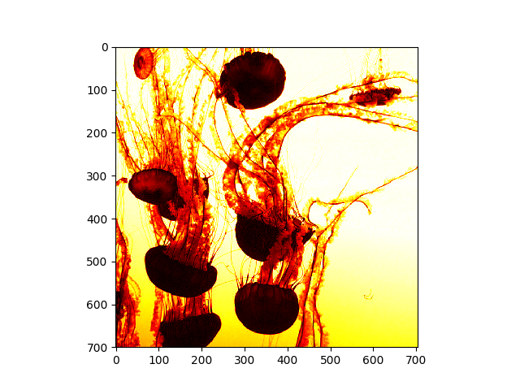

```python
plt.imshow(J['blue'].data, cmap='hot')
```

```python
plt.close()
```

`Collection` objects can also be indexed by position (integer). The green channel is:

```python
J[1]
```

```
<green: a Trieste 2-D Array>
```

It is also possible to iterate through the contents of the `Collection`:

```python
for channel in J:
    print(channel)
```

```
<red: a Trieste 2-D Array>
<green: a Trieste 2-D Array>
<blue: a Trieste 2-D Array>
```

The caption that was stored in the metadata is easily accessible:

```python
J.metadata['caption']
```

```
'This is a caption for the photo taken in 2010 at the Monterey Bay Aquarium.'
```

If you use IPython or a Jupyter notebook to create an object, the session history, leading up to the creation of the file, is stored so that the person reading the file can figure out how the file was created:

```python
J.print_history()
```

```
%pylab notebook
import trieste as tr
image = plt.imread("IMG_2054.jpg")
plt.imshow(image)
plt.close()
red = image[:,:,0]

green = image[:,:,1]

blue = image[:,:,2]
R = tr.Array(red)

G = tr.Array(green)

B = tr.Array(blue)
meta = {'caption': 'This is a caption for the photo taken in 2010 at the Monterey Bay Aquarium.'}
jelly = tr.Collection([R,G,B], name='jellyfish', metadata=meta)
read_me = """
This is potentially a long document describing the content of this Collection.
"""
jelly.set_readme(read_me)
jelly.save_as('jellies')
```

The `Collection`'s metadata contains lots of additional information about its creation process:

```python
J.metadata['author']
```

```
'nathaniel'
```

```python
J.metadata['hostname']
```

```
'idiusmobile'
```

```python
J.metadata['author_working_dir']
```

```
'/home/nathaniel/devel/trieste/examples'
```

```python
J.metadata['platform']
```

```
'Linux-4.13.0-36-generic-x86_64-with-Ubuntu-16.04-xenial'
```

all metadata:

```python
J.metadata
```

```
{'OS': 'Linux',
 'architecture': 'x86_64',
 'author': 'nathaniel',
 'author_working_dir': '/home/nathaniel/devel/trieste/examples',
 'caption': 'This is a caption for the photo taken in 2010 at the Monterey Bay Aquarium.',
 'creation_date': 'Wed Mar  7 22:06:09 2018',
 'creation_time': 1520489169.6355786,
 'doc': '\nThis is potentially a long document describing the content of this Collection.\n',
 'hostname': 'idiusmobile',
 'ipython_history': '%pylab notebook\nimport trieste as tr\nimage = plt.imread("IMG_2054.jpg")\nplt.imshow(image)\nplt.close()\nred = image[:,:,0]\n\ngreen = image[:,:,1]\n\nblue = image[:,:,2]\nR = tr.Array(red)\n\nG = tr.Array(green)\n\nB = tr.Array(blue)\nmeta = {\'caption\': \'This is a caption …
 'n_objects': 1,
 'name': 'jellyfish',
 'numpy_version': (1, 14, 1),
 'platform': 'Linux-4.13.0-36-generic-x86_64-with-Ubuntu-16.04-xenial',
 'python_implementation': 'CPython',
 'python_version': (3, 6, 3),
 'trieste_version': (0, 1, 1),
 'type': '2-D Array Collection'}
```